# Diving Deeper: Understanding REDCapTidieR Data Tibbles

## The Block Matrix

In the Getting Started vignette, we stated that importing records from complex REDCap projects via the REDCap API can be *ugly*. In this section we will describe what we mean by this in more precise language.

The `REDCapR::redcap_read_oneshot()` function pulls data from a REDCap project via the REDCap API and provides it to the R environment without performing much processing. It returns a list with an element named `data` that contains all of the data of the project as a single data frame.

Below, we use this function to import data from the Superhero REDCap database, which contains a **nonrepeating instrument** `heroes_information` and a **repeating instrument** `super_hero_powers`. We use `rmarkdown::paged_table()` to allow you to explore this large data frame in the browser.

```r
superheroes_token <- "123456789ABCDEF123456789ABCDEF04"
redcap_uri <- "https://my.institution.edu/redcap/api/"
```

```r
superheroes_ugly <- REDCapR::redcap_read_oneshot(redcap_uri, superheroes_token)$data

superheroes_ugly |>
  rmarkdown::paged_table()
```

| record_id | redcap_repeat_instrument | redcap_repeat_instance | name | gender | eye_color | race | hair_color | height | weight | publisher | skin_color | alignment | heroes_information_complete | power | super_hero_powers_complete |
| --- | --- | --- | --- | --- | --- | --- | --- | --- | --- | --- | --- | --- | --- | --- | --- |
| 0 | NA | NA | A-Bomb | Male | yellow | Human | No Hair | 203.0 | 441 | Marvel Comics | - | good | 0 | NA | NA |
| 0 | super_hero_powers | 1 | NA | NA | NA | NA | NA | NA | NA | NA | NA | NA | NA | Accelerated Healing | 0 |
| 0 | super_hero_powers | 2 | NA | NA | NA | NA | NA | NA | NA | NA | NA | NA | NA | Durability | 0 |
| 0 | super_hero_powers | 3 | NA | NA | NA | NA | NA | NA | NA | NA | NA | NA | NA | Longevity | 0 |
| 0 | super_hero_powers | 4 | NA | NA | NA | NA | NA | NA | NA | NA | NA | NA | NA | Super Strength | 0 |
| 0 | super_hero_powers | 5 | NA | NA | NA | NA | NA | NA | NA | NA | NA | NA | NA | Stamina | 0 |
| 0 | super_hero_powers | 6 | NA | NA | NA | NA | NA | NA | NA | NA | NA | NA | NA | Camouflage | 0 |
| 0 | super_hero_powers | 7 | NA | NA | NA | NA | NA | NA | NA | NA | NA | NA | NA | Self-Sustenance | 0 |
| 1 | NA | NA | Abe Sapien | Male | blue | Icthyo Sapien | No Hair | 191.0 | 65 | Dark Horse Comics | blue | good | 0 | NA | NA |
| 1 | super_hero_powers | 1 | NA | NA | NA | NA | NA | NA | NA | NA | NA | NA | NA | Agility | 0 |

[output cut: 6690 more lines]

This data structure is called a [block matrix](https://en.wikipedia.org/wiki/Block_matrix). It’s what happens when REDCap mashes the contents of a project that has both repeating and nonrepeating instruments into a single table.

While it may seem a good idea to have everything in one data frame, there are significant downsides, including:

- It’s unwieldy! Although there are only 734 superheroes in the data set, there are 6,700 rows. Every transformation first requires whittling down a huge data set.
- There are a lot of `NA` values. Many of these `NA` values don’t represent fields left blank during data entry but instead are an artifact of how the table is generated.
- Metadata that would be helpful is missing. For example, it’s not possible to determine which columns are associated with a specific instrument for nonrepeating instruments.
- The meaning of a row in the data set is inconsistent. Some rows represent observations on a per-record level (i.e. those derived from nonrepeating instruments) and others represent observations on a per-repeat-instance level (i.e. those derived from repeating instruments). This technically violates the definition of [Tidy Data](https://www.jstatsoft.org/article/view/v059i10) because multiple types of observational units are stored in the same table.

## Structure of REDCapTidieR Data Tibbles

REDCapTidieR breaks the block matrix up into **data tibbles**, one for each instrument. REDCapTidieR then collects the data tibbles as a **list column** in a special object we call the **supertibble**.

These data tibbles are **tidier** than the block matrix because one instrument can only be repeating or nonrepeating, and therefore each data tibble can only have one type of observational unit stored inside of it. Each data tibble has consistent granularity.

Let’s take a look at the data tibbles derived from the Superhero database and contrast them with the block matrix. Consider `heroes_information`, which contains data from a **nonrepeating** instrument. This tibble is much smaller than the block matrix at 734 rows by 12 columns, and there are no `NA`s. The data tibble’s name `heroes_information` is descriptive. REDCapTidieR knows the names of all instruments because in addition to querying the project’s data it also queries the project’s metadata which describes, among other things, the names of REDCap instruments. Each entry has the same granularity, one **superhero**, identified by its `record_id`. A number of data columns follow, starting with `name`, `gender`, `eye_color`, `race`, etc. These columns are in the same order as on the REDCap instrument. The last column of a REDCapTidieR data tibble is always `form_status_complete` which indicates whether the instrument has been marked as completed.

```r
library(REDCapTidieR)

read_redcap(redcap_uri, superheroes_token) |>
  bind_tibbles()

heroes_information |>
  rmarkdown::paged_table()
```

| record_id | name | gender | eye_color | race | hair_color | height | weight | publisher | skin_color | alignment | form_status_complete |
| --- | --- | --- | --- | --- | --- | --- | --- | --- | --- | --- | --- |
| 0 | A-Bomb | Male | yellow | Human | No Hair | 203.0 | 441 | Marvel Comics | - | good | Incomplete |
| 1 | Abe Sapien | Male | blue | Icthyo Sapien | No Hair | 191.0 | 65 | Dark Horse Comics | blue | good | Incomplete |
| 2 | Abin Sur | Male | blue | Ungaran | No Hair | 185.0 | 90 | DC Comics | red | good | Incomplete |
| 3 | Abomination | Male | green | Human / Radiation | No Hair | 203.0 | 441 | Marvel Comics | - | bad | Incomplete |
| 4 | Abraxas | Male | blue | Cosmic Entity | Black | -99.0 | -99 | Marvel Comics | - | bad | Incomplete |
| 5 | Absorbing Man | Male | blue | Human | No Hair | 193.0 | 122 | Marvel Comics | - | bad | Incomplete |
| 6 | Adam Monroe | Male | blue | - | Blond | -99.0 | -99 | NBC - Heroes | - | good | Incomplete |
| 7 | Adam Strange | Male | blue | Human | Blond | 185.0 | 88 | DC Comics | - | good | Incomplete |
| 8 | Agent 13 | Female | blue | - | Blond | 173.0 | 61 | Marvel Comics | - | good | Incomplete |
| 9 | Agent Bob | Male | brown | Human | Brown | 178.0 | 81 | Marvel Comics | - | good | Incomplete |

[output cut: 724 more lines]

Now consider the `super_hero_powers` table, which contains data from a **repeating** instrument. In addition to `record_id` there is a `redcap_form_instance` column. The granularity of each row is one **superpower per superhero**, identified by its `record_id` and `redcap_form_instance`. Because these two columns uniquely identify a row in the data tibble, we call them **identifier columns**. In the REDCapTidieR supertibble, identifier columns always come first, followed by [**data columns**] and finally the `form_status_complete` column.

```r
super_hero_powers |>
  rmarkdown::paged_table()
```

| record_id | redcap_form_instance | power | form_status_complete |
| --- | --- | --- | --- |
| 0 | 1 | Accelerated Healing | Incomplete |
| 0 | 2 | Durability | Incomplete |
| 0 | 3 | Longevity | Incomplete |
| 0 | 4 | Super Strength | Incomplete |
| 0 | 5 | Stamina | Incomplete |
| 0 | 6 | Camouflage | Incomplete |
| 0 | 7 | Self-Sustenance | Incomplete |
| 1 | 1 | Agility | Incomplete |
| 1 | 2 | Accelerated Healing | Incomplete |
| 1 | 3 | Cold Resistance | Incomplete |

[output cut: 5956 more lines]

## Longitudinal REDCap projects

REDCap supports two main mechanisms to allow collecting the same data multiple times: **repeating instruments** and **longitudinal projects**. In addition, a longitudinal project may have **arms** and/or **repeating events**.

The **granularity** of each table (i.e. the observational unit that a single row represents) depends on the structure of the project (classic, longitudinal, longitudinal with multiple arms), the structure of the instrument (repeating or nonrepeating), and, for longitudinal projects, the structure of the event (repeating or nonrepeating). Note that REDCap does not support repeating instruments inside a repeating event. REDCapTidieR generates **identifier columns** according to the following table:

| **Instrument Structure** | **Event Structure** | **Classic** | **Longitudinal, one arm** | **Longitudinal, multi-arm** |
| --- | --- | --- | --- | --- |
| **Nonrepeating** | **Nonrepeating** | `record_id` | `record_id` + `redcap_event` | `record_id` + `redcap_event` + `redcap_arm` |
| **Repeating** | **Nonrepeating** | `record_id` + `redcap_form_instance` | `record_id` + `redcap_form_instance` + `redcap_event` | `record_id` + `redcap_form_instance` + `redcap_event` + `redcap_arm` |
| **Nonrepeating** | **Repeating** | N/A | `record_id` + `redcap_event_instance` + `redcap_event` | `record_id` + `redcap_event_instance` + `redcap_event` + `redcap_arm` |
| **Repeating** | **Repeating** | Not Supported | Not Supported | Not Supported |

> Note: Taken in combination, the identifier columns of any REDCapTidieR tibble are guaranteed to be **unique** and can therefore be used as **composite primary key**. This makes it easy to join REDCapTidieR tibbles to one another!

By default, REDCap names the record ID field `record_id`, but this can be changed inside the REDCap project, and REDCapTidieR is smart enough to handle this. For example, if the record ID field was renamed to `subject_id` then the record ID column of each data tibble would be `subject_id`. Whatever its name, the record ID column is always the first identifier column and is always the first column of a REDCapTidieR data tibble. Additional columns are generated in the order shown in the table above.

Let’s look at a REDCap database you might use to capture data for a clinical trial. This is a longitudinal database that assesses some data (e.g. demographics) just once at enrollment, and other data (e.g. physical exam or labs) multiple times at pre-defined study visits. We use `dplyr::select()` here to highlight instrument names and whether or not each instrument is repeating. This database has six nonrepeating and three repeating instruments.

```r
longitudinal_token <- "123456789ABCDEF123456789ABCDEF06"
```

```r
library(REDCapTidieR)

longitudinal <- read_redcap(redcap_uri, longitudinal_token)

longitudinal |>
  dplyr::select(redcap_form_name, redcap_form_label, structure) |>
  rmarkdown::paged_table()
```

| redcap_form_name | redcap_form_label | structure |
| --- | --- | --- |
| demographics | Demographics | nonrepeating |
| medical_history | Medical History | repeating |
| eligibility | Eligibility | nonrepeating |
| consent | Consent | repeating |
| physical_exam | Physical Exam | nonrepeating |
| hematology | Hematology | nonrepeating |
| chemistry | Chemistry | nonrepeating |
| disease_assessment | Disease Assessment | nonrepeating |
| adverse_events | Adverse Events | repeating |

The `demographics` instrument is nonrepeating. The granularity is one row per study subject per event, but since it is only designated for a single event, it is really one row per study subject. The `redcap_event` column identifies the name of the event with which the instrument is associated: `screening__enrollm` (Screening and Enrollment).

```r
longitudinal |>
  bind_tibbles()

demographics |>
  rmarkdown::paged_table()
```

| subject_id | redcap_event | demo_mrn | demo_last_name | demo_first_name | demo_birth_date | demo_age | demo_sex | demo_race | demo_race_specify | demo_ethnicity | form_status_complete |
| --- | --- | --- | --- | --- | --- | --- | --- | --- | --- | --- | --- |
| 001-123-001 | screening__enrollm | 12345678 | French | Maximilian | 1983-11-02 | 39.00 | Male | White | NA | Not Hispanic or Latino | Complete |
| 001-123-002 | screening__enrollm | 87205837 | Myers | Mike | 1972-11-29 | 49.93 | Male | White | NA | Not Hispanic or Latino | Complete |
| 001-123-003 | screening__enrollm | 87374342 | Lavender | Cherie | 1976-07-15 | 46.32 | Female | White | NA | Not Hispanic or Latino | Complete |

The `chemistry` instrument is nonrepeating as well. However, it is designated for multiple events because chemistry labs are drawn at multiple study visits. The `redcap_event` column shows that we have `chemistry` data from four different events. The granularity is one row per study subject per event. Each of the three subjects has multiple rows. Each row is identified by the combination of `subject_id` and `redcap_event`.

```r
chemistry |>
  rmarkdown::paged_table()
```

| subject_id | redcap_event | chem_performed_date | chem_sodium_mmoll | chem_potassium_mmoll | chem_bun_mgdl | chem_creatinine_mgdl | chem_glucose_mgdl | chem_calcium_mgdl | chem_protein_gdl | chem_albumin_gdl | chem_phosphatase_ul | chem_alt_ul | chem_ast_ul | form_status_complete |
| --- | --- | --- | --- | --- | --- | --- | --- | --- | --- | --- | --- | --- | --- | --- |
| 001-123-001 | screening__enrollm | 2022-11-02 | 130 | 6.0 | 15 | 0.03 | 130 | 10.0 | 4.0 | 6.0 | 60 | 450 | 350 | Complete |
| 001-123-001 | preinfusion | 2022-11-17 | 130 | 7.0 | 15 | 3.00 | 150 | 12.0 | 5.0 | 7.0 | 120 | 488 | 324 | Complete |
| 001-123-001 | infusion | 2022-11-14 | 110 | 3.0 | 2 | 0.00 | 50 | 6.0 | 4.0 | 2.0 | 10 | 3 | 10 | Complete |
| 001-123-001 | 1_day_followup | 2022-11-15 | 110 | 3.0 | 3 | 0.06 | 75 | 7.0 | 6.6 | 2.9 | 15 | 34 | 45 | Complete |
| 001-123-002 | screening__enrollm | 2022-11-04 | 135 | 6.0 | 15 | 0.06 | 96 | 10.4 | 6.9 | 8.0 | 130 | 550 | 310 | Complete |
| 001-123-002 | preinfusion | 2022-11-08 | 110 | 45.0 | 3 | 2.00 | 100 | 12.0 | 8.0 | 8.0 | 150 | 46 | 37 | Complete |
| 001-123-002 | infusion | 2022-11-16 | 130 | 4.1 | 3 | 0.03 | 110 | 8.9 | 4.0 | 2.9 | 130 | 550 | 324 | Complete |
| 001-123-003 | screening__enrollm | 2022-11-09 | 140 | 6.0 | 28 | 0.07 | 110 | 11.0 | 8.0 | 7.0 | 45 | 350 | 110 | Complete |
| 001-123-003 | preinfusion | 2022-11-15 | 139 | 5.0 | 2 | 0.20 | 80 | 9.4 | 5.6 | 7.0 | 60 | 550 | 350 | Complete |

The `adverse_events` instrument is **repeating**. Since adverse events aren’t tied to specific study visits, and a patient can have any number of different adverse events at any time, it makes sense to designate this instrument to a single special event `adverse_event`, which is what we’ve done here. The granularity of this table is one row per study subject per repeat instance per event. However since it is only designated for a single event, it is really one row per study subject per repeat instance. The first subject has three adverse events listed, and the second subject has two.

```r
adverse_events |>
  rmarkdown::paged_table()
```

| subject_id | redcap_event | redcap_form_instance | adverse_event_meddra_soc | adverse_event_meddra_ae_code | adverse_event_meddra_ae_code_specify | adverse_event_details | adverse_event_onset | adverse_event_serious | adverse_event_serious_why | adverse_event_grade | adverse_event_start_date_known | adverse_event_start_date | adverse_event_stop_date_known | adverse_event_stop_date | adverse_event_stop_date_specify | adverse_event_relationship_product | adverse_event_relationship_other___apheresis | adverse_event_relationship_other___ld_chemo | adverse_event_relationship_other___soc_treatment | adverse_event_relationship_other___underlying_disease | adverse_event_relationship_other___other_research_proc | adverse_event_relationship_other___con_meds | adverse_event_relationship_other___other | adverse_event_relationship_other___none | adverse_event_relationship_other_specify | adverse_event_expected | adverse_event_study_treatment_action | adverse_event_participant_status | adverse_event_ae_action | … |
| --- | --- | --- | --- | --- | --- | --- | --- | --- | --- | --- | --- | --- | --- | --- | --- | --- | --- | --- | --- | --- | --- | --- | --- | --- | --- | --- | --- | --- | --- | --- |
| 001-123-001 | adverse_event | 1 | Endocrine Disorder | Eyelid function disorder | NA | intermittent | Before LD Chemo | FALSE | NA | Grade 2 | TRUE | 2022-11-02 | TRUE | 2022-11-04 | NA | Unrelated | FALSE | FALSE | FALSE | TRUE | FALSE | TRUE | FALSE | FALSE | NA | TRUE | No Action Taken | Recovered or Resolved | TRUE | … |
| 001-123-001 | adverse_event | 2 | Gastrointestinal Disorder | Diarrhea | NA | intermittent | Before LD Chemo | FALSE | NA | Grade 1 | TRUE | 2022-11-05 | TRUE | 2022-11-17 | NA | Unrelated | FALSE | FALSE | FALSE | FALSE | FALSE | FALSE | FALSE | TRUE | NA | FALSE | No Action Taken | Recovered or Resolved | TRUE | … |
| 001-123-001 | adverse_event | 3 | Skin Disorder | Rash maculo-papular | NA | left cheek | Before LD Chemo | FALSE | NA | Grade 1 | TRUE | 2022-11-08 | FALSE |  | Event/Occurrence is Ongoing | Unrelated | FALSE | FALSE | FALSE | FALSE | FALSE | TRUE | FALSE | FALSE | NA | FALSE | No Action Taken | Recovered or Resolved | FALSE | … |
| 001-123-002 | adverse_event | 1 | Infection and infestation | Flu like symptoms | NA | NA | Before LD Chemo | FALSE | NA | Grade 2 | TRUE | 2022-11-08 | TRUE | 2022-11-10 | NA | Unrelated | FALSE | FALSE | FALSE | FALSE | FALSE | FALSE | FALSE | TRUE | NA | FALSE | No Action Taken | Recovered or Resolved | FALSE | … |
| 001-123-002 | adverse_event | 2 | Eye Disorder | Dry eye | NA | intermittent | Before LD Chemo | FALSE | NA | Grade 1 | TRUE | 2022-11-07 | FALSE |  | Event/Occurrence is Ongoing | Unrelated | FALSE | FALSE | FALSE | FALSE | FALSE | TRUE | TRUE | FALSE | weather | FALSE | No Action Taken | Not Recovered or Not Resolved | TRUE | … |

It is possible to have a repeating instrument designated to multiple events, however this is an uncommon pattern. REDCapTidieR supports this scenario as well.

REDCapTidieR does *not* allow you to have the same instrument designated both as a repeating and as a nonrepeating instrument in different events. It will throw an error if it detects this.

The `unscheduled` **event** is a **repeating event**. Like adverse events, unscheduled visits aren’t tied to a pre-determined study visit, and a patient could have zero, one, or multiple unscheduled visits. On the other hand, you might want to record the same kinds of data for an unscheduled visit as for a pre-determined regular visit and collect data in the same instruments, for example `physical_exam` and `hematology`. The granularity of these tables is one row per study subject per event per *event instance*. The subject had two unscheduled visits. `redcap_event_instance` allows us to match `physical_exam` and `hematology` responses which occurred on the same unscheduled visit.

```r
physical_exam |>
  dplyr::filter(redcap_event == "unscheduled") |>
  rmarkdown::paged_table()

hematology |>
  dplyr::filter(redcap_event == "unscheduled") |>
  rmarkdown::paged_table()
```

| subject_id | redcap_event | redcap_event_instance | physical_capture | physical_capture_infusion_sql | physical_capture_visit | physical_performed | physical_performed_date | physical_performance_scale | physical_performance_score | physical_findings | physical_findings_specify | form_status_complete |
| --- | --- | --- | --- | --- | --- | --- | --- | --- | --- | --- | --- | --- |
| 001-123-001 | unscheduled | 1 | FALSE | NA | NA | TRUE | 2022-12-01 | Karnofsky Scale | 50 | FALSE | NA | Complete |
| 001-123-001 | unscheduled | 2 | FALSE | NA | NA | TRUE | 2022-12-15 | Karnofsky Scale | 80 | FALSE | NA | Complete |

| subject_id | redcap_event | redcap_event_instance | hemat_capture | hemat_capture_infusion_sql | hemat_capture_visit | hemat_performed | hemat_performed_specify | hemat_performed_date | hemat_laboratory | hemat_laboratory_specify | hemat_wbc_avail | hemat_wbc_ct | hemat_wbc_clinical_signif | hemat_rbc_avail | hemat_rbc_ct | hemat_rbc_clinical_signif | hemat_hgb_avail | hemat_hgb_gdl | hemat_hgb_clinical_signif | hemat_hct_avail | hemat_hct_pct | hemat_hct_clinical_signif | hemat_plt_avail | hemat_plt_ct | hemat_plt_clinical_signif | hemat_anc_avail | hemat_anc_ct | hemat_anc_clinical_signif | hemat_alc_avail | … |
| --- | --- | --- | --- | --- | --- | --- | --- | --- | --- | --- | --- | --- | --- | --- | --- | --- | --- | --- | --- | --- | --- | --- | --- | --- | --- | --- | --- | --- | --- | --- |
| 001-123-001 | unscheduled | 1 | FALSE | NA | NA | TRUE | NA | 2022-12-01 | Children's Hospital of Philadelphia | NA | TRUE | 10 | Normal | TRUE | 5 | Normal | NA | NA | NA | NA | NA | NA | NA | NA | NA | NA | NA | NA | NA | … |

Note that REDCapTidieR allows for an instrument to be associated with both repeating and nonrepeating events at the same time. In this case, the the `redcap_event_instance` column will be `NA` in rows that correspond with data captured as part of a nonrepeating event.

REDCapTidieR supports projects with multiple arms. If you have a project with multiple arms, there will be an additional column `redcap_arm` to identify the arm that the row is associated with.

## Categorical variables

REDCapTidieR performs a number of opinionated transformations on categorical fields to streamline exploring them and working with them.

Fields that are of type `yesno` or `truefalse` are converted to **logical** variables.

```r
adverse_events$adverse_event_serious |>
  dplyr::glimpse()
```

```
#>  logi [1:5] FALSE FALSE FALSE FALSE FALSE
```

Fields of single-answer categorical type (`dropdown`, `radio`) are converted to **factor** variables by default. REDCapTidieR constructs this factor in such a way that the all possible choices defined in REDCap are represented as factor levels, and that the order of the factor levels is the same as the order of choices in REDCap.

Consider the Field Editor for the `adverse_event_grade` variable which is a single-answer `radio` field. There are five choices for this field. Choices have **raw values** and **choice labels**, separated by a comma. Here, the raw values are `1`, `2`, `3`, `4`, and `5`, and their associated choice labels are `Grade 1`, `Grade 2`, `Grade 3`, `Grade 4`, and `Grade 5`.

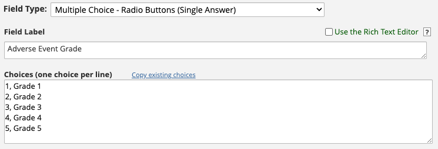

REDCap field editor showing the choices of a single-answer field

REDCapTidieR preserves all the possible choices as levels even if not all of them are represented in the data. This makes it possible to discover all of the different choices. For example, even though we have only Grade 1 and 2 adverse events in the data, we can see that there are 5 possible grades.

```r
adverse_events$adverse_event_grade
```

```
#> [1] Grade 2 Grade 1 Grade 1 Grade 2 Grade 1
#> Levels: Grade 1 Grade 2 Grade 3 Grade 4 Grade 5
```

Adverse event grades are intrinsically ordered. When a multiple choice field has intrinsically ordered choices, those choices are usually presented in the proper order. Since REDCapTidieR preserves the order of choices from REDCap, you can convert intrinsically ordered variables to ordered factors.

```r
ae_grade <- adverse_events$adverse_event_grade

ae_grade |>
  factor(ordered = TRUE, levels = levels(ae_grade))
```

```
#> [1] Grade 2 Grade 1 Grade 1 Grade 2 Grade 1
#> Levels: Grade 1 < Grade 2 < Grade 3 < Grade 4 < Grade 5
```

Fields of the multi-answer `checkbox` type are treated in a special way. REDCapTidieR *expands* these fields into multiple columns. Each of these derived columns represents one **choice** and is coded as a **logical variable**.

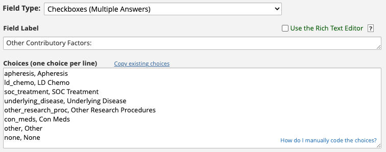

REDCap field editor showing the choices of a multi-answer field

> We recommend that for multi-answer `checkbox` fields you make the raw value a human readable word as we do in the above example.

REDCapTidieR will construct the name of each variable from the name of the field, followed by three underscores, followed by the **raw** value of the choice defined in REDCap. Here are the variables REDCapTidieR generates from the `adverse_event_relationship_other` field:

```r
adverse_events |>
  dplyr::select(dplyr::starts_with("adverse_event_relationship_other___")) |>
  dplyr::glimpse()
```

```
#> Rows: 5
#> Columns: 8
#> $ adverse_event_relationship_other___apheresis           <lgl> FALSE, FALSE, F…
#> $ adverse_event_relationship_other___ld_chemo            <lgl> FALSE, FALSE, F…
#> $ adverse_event_relationship_other___soc_treatment       <lgl> FALSE, FALSE, F…
#> $ adverse_event_relationship_other___underlying_disease  <lgl> TRUE, FALSE, FA…
#> $ adverse_event_relationship_other___other_research_proc <lgl> FALSE, FALSE, F…
#> $ adverse_event_relationship_other___con_meds            <lgl> TRUE, FALSE, TR…
#> $ adverse_event_relationship_other___other               <lgl> FALSE, FALSE, F…
#> $ adverse_event_relationship_other___none                <lgl> FALSE, TRUE, FA…
```

## Data Access Groups

Some REDCap projects may use Data Access Groups (DAGs) to assign specific user privileges and record-level access to entries within the project. DAGs are frequently used in multi-center projects where the data from an individual centers needs to be isolated and protected from users belonging to other centers.

If a project has DAGs enabled, by default a column named `redcap_data_access_group` will appear in each data tibble after the identifier columns.

```r
redcap_project_with_dags <- read_redcap(redcap_uri, dag_token)

redcap_project_with_dags |>
  extract_tibble("non_repeat_form_1") |>
  rmarkdown::paged_table()
```

| record_id | redcap_data_access_group | non_repeat_form_1_txt | form_status_complete |
| --- | --- | --- | --- |
| 1 | dag1 | NA | Complete |
| 2 | dag2 | NA | Complete |
| 3 | dag3 | NA | Complete |
| 4 | NA | NA | Incomplete |

## Surveys

Instruments that are used to generate REDCap surveys generate additional data columns:

- `redcap_survey_timestamp`: the time at which the survey was competed
- `redcap_survey_identifier`: the participant identifier. This will be `NA` if the Participant Identifier feature in REDCap is disabled.

These columns are placed after all of the other data columns and prior to the `form_status_complete` column.

```r
survey <- read_redcap(redcap_uri, survey_token) |>
  extract_tibble("survey")

survey |>
  dplyr::glimpse()
```

```
#> Rows: 4
#> Columns: 9
#> $ record_id                <dbl> 1, 2, 3, 4
#> $ survey_yesno             <lgl> TRUE, FALSE, NA, NA
#> $ survey_radio             <fct> Choice 1, Choice 2, NA, NA
#> $ survey_checkbox___one    <lgl> FALSE, FALSE, FALSE, FALSE
#> $ survey_checkbox___two    <lgl> TRUE, TRUE, FALSE, FALSE
#> $ survey_checkbox___three  <lgl> TRUE, TRUE, FALSE, FALSE
#> $ redcap_survey_identifier <lgl> NA, NA, NA, NA
#> $ redcap_survey_timestamp  <dttm> 2022-11-09 10:33:35, NA, NA, NA
#> $ form_status_complete     <fct> Complete, Incomplete, Incomplete, Incomplete
```

## Summary

In summary, here are the rules by which REDCapTidieR constructs data tibbles:

1. One data tibble is built for each instrument.
2. The first column is always the record ID column which is derived from the record ID field.
3. Additional identifier columns may follow the record ID column, depending on the structure of the instrument and the structure of the project (see the table above).
4. If the project has data access groups enabled, a column identifying the data access column will follow here.
5. Next, data columns appear in the same order as in the REDCap instrument. True/false type fields are converted to logical columns. Single-answer categorical fields are converted to factor columns. Multi-answer checkbox fields are expanded to a set of logical columns, one for each choice.
6. If the instrument is used as a survey, the survey timestamp and identifier columns will appear next.
7. The final column is always `form_status_complete`.